# Homework-21084

Han Wang

2021-12-19

```r
library(knitr)
```

# 2021-09-16

## Question

Use **knitr** to produce at least 3 examples (texts, figures, tables).

## Answer

### Texts

Dataset **mtcars** is a data frame extracted from the 1974 *Motor Trend* US magazine, and comprises fuel consumption and 10 aspects of automobile design and performance for 32 automobiles (1973–74 models). *Mpg* is miles/(US) gallon, *cyl* is the number of cylinders, *disp* is displacement (cu.in.), *hp* means gross horsepower, *drat* is rear axle ratio, *wt* is weight (1000 lbs), *qsec* represents 1/4 mile time, *vs* is engine (0 = V-shaped, 1 = straight), *am* is transmission (0 = automatic, 1 = manual), *gear* is the number of forward gears and *carb* is the number of carburetors.

### Tables

We randomly select 12 data from the Dataset to create a table with 12 rows and 12 columns.

```r
data("mtcars")
set.seed(1234)
knitr::kable(mtcars[sort(sample(1:nrow(mtcars),12)),])
```

|  | mpg | cyl | disp | hp | drat | wt | qsec | vs | am | gear | carb |
| --- | --- | --- | --- | --- | --- | --- | --- | --- | --- | --- | --- |
| Hornet 4 Drive | 21.4 | 6 | 258.0 | 110 | 3.08 | 3.215 | 19.44 | 1 | 0 | 3 | 1 |
| Hornet Sportabout | 18.7 | 8 | 360.0 | 175 | 3.15 | 3.440 | 17.02 | 0 | 0 | 3 | 2 |
| Valiant | 18.1 | 6 | 225.0 | 105 | 2.76 | 3.460 | 20.22 | 1 | 0 | 3 | 1 |
| Merc 230 | 22.8 | 4 | 140.8 | 95 | 3.92 | 3.150 | 22.90 | 1 | 0 | 4 | 2 |
| Merc 450SE | 16.4 | 8 | 275.8 | 180 | 3.07 | 4.070 | 17.40 | 0 | 0 | 3 | 3 |
| Cadillac Fleetwood | 10.4 | 8 | 472.0 | 205 | 2.93 | 5.250 | 17.98 | 0 | 0 | 3 | 4 |
| Lincoln Continental | 10.4 | 8 | 460.0 | 215 | 3.00 | 5.424 | 17.82 | 0 | 0 | 3 | 4 |
| Dodge Challenger | 15.5 | 8 | 318.0 | 150 | 2.76 | 3.520 | 16.87 | 0 | 0 | 3 | 2 |
| Fiat X1-9 | 27.3 | 4 | 79.0 | 66 | 4.08 | 1.935 | 18.90 | 1 | 1 | 4 | 1 |
| Lotus Europa | 30.4 | 4 | 95.1 | 113 | 3.77 | 1.513 | 16.90 | 1 | 1 | 5 | 2 |
| Maserati Bora | 15.0 | 8 | 301.0 | 335 | 3.54 | 3.570 | 14.60 | 0 | 1 | 5 | 8 |
| Volvo 142E | 21.4 | 4 | 121.0 | 109 | 4.11 | 2.780 | 18.60 | 1 | 1 | 4 | 2 |

### Figures

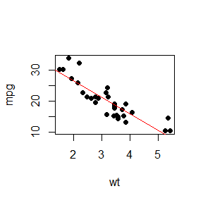

```r
plot(mtcars$wt,mtcars$mpg,pch=16,xlab = "wt",ylab = "mpg")
abline(lm(mtcars$mpg~mtcars$wt),col="red")
```

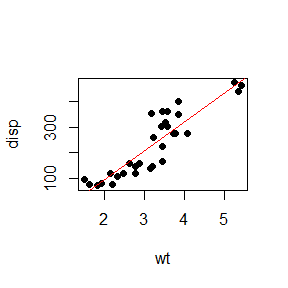

```r
plot(mtcars$wt,mtcars$disp,pch=16,xlab = "wt",ylab = "disp")
abline(lm(mtcars$disp~mtcars$wt),col="red")
```

# 2021-09-23

## Question

Exercises 3.4, 3.11, and 3.20 (pages 94-96, Statistical Computating with R).

## Answer

### 3.4

The Rayleigh density [156, Ch. 18] is
$$\begin{equation}
f(x)=\frac{x}{\sigma^2}e^{-x^2/(2\sigma^2)},\qquad x\ge 0,\ \sigma>0.
\end{equation}$$
Develop an algorithm to generate random samples from a Rayleigh($σ$) distribution. Generate Rayleigh($σ$) samples for several choices of $σ > 0$ and check that the mode of the generated samples is close to the theoretical mode $σ$ (check the histogram).

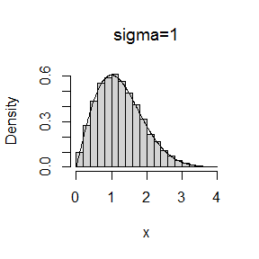

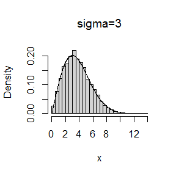

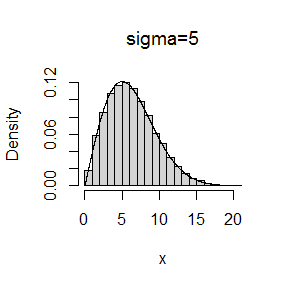

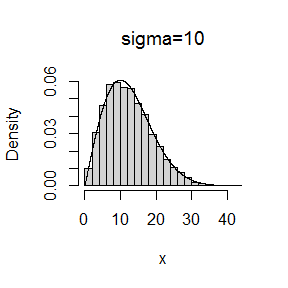

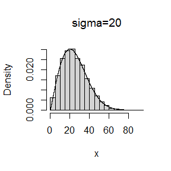

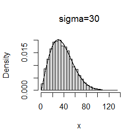

```r
rayleigh<-function(sigma){#inverse transform algorithm
  n<-10000
  u<-runif(n)#Uniform(0,1)
  y<--2*log(1-u)#inverse transform of exponential distribution
  x<-sigma*sqrt(y)#generate random samples from the Rayleigh distribution
  hist(x, prob=T,main=bquote('sigma='*.(sigma)),nclass=20)
  y<-seq(0,ceiling(max(x)),0.01)
  lines(y,y*exp(-y*y/2/sigma^2)/sigma^2)
}
sigma<-c(1,3,5,10,20,30)
for (i in 1:length(sigma)) {
  rayleigh(sigma[i])
}
```

The histograms show the algorithm is good.

### 3.11

Generate a random sample of size 1000 from a normal location mixture. The components of the mixture have $N(0,1)$ and $N(3, 1)$ distributions with mixing probabilities $p_1$ and $p_2 = 1 − p_1$. Graph the histogram of the sample with density superimposed, for $p_1 = 0.75$. Repeat with different values for p1 and observe whether the empirical distribution of the mixture appears to be bimodal. Make a conjecture about the values of p1 that produce bimodal mixtures.

```r
loc.mix<-function(p1){#generate 1000 samples from the mormal location mixture
  n1<-rbinom(1,1000,p1)
  n2<-1000-n1
  x1<-rnorm(n1,0,1)
  x2<-rnorm(n2,3,1)
  x<-c(x1,x2)
  hist(x, prob=T,main=bquote('p1='*.(p1)),nclass=20)
}
cat('p1=0.75')
```

```
## p1=0.75
```

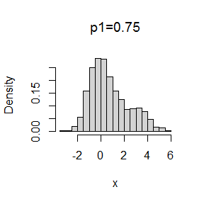

```r
loc.mix(0.75)
```

```r
for (p in seq(from = 0.1, to = 0.9, by = 0.1)) {
  loc.mix(p)
}
```

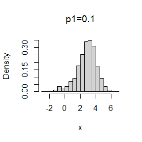

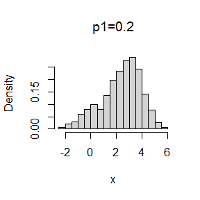

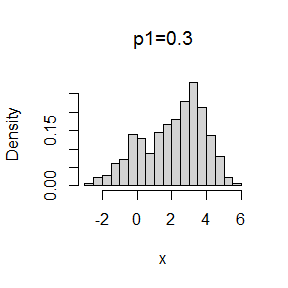

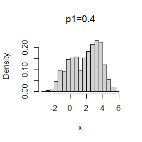

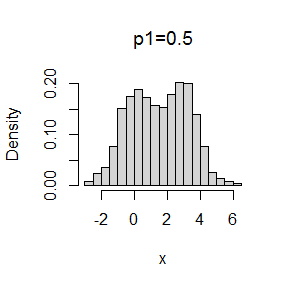

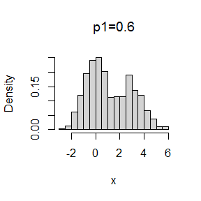

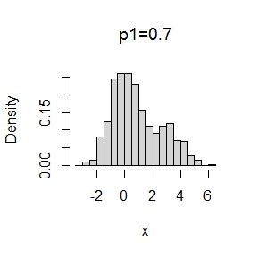

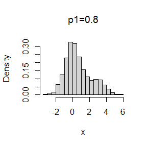

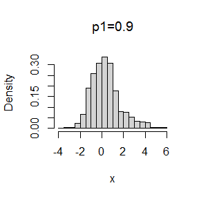

### 3.20

A compound Poisson process is a stochastic process $\{X(t),\ t \ge 0\}$ that can be represented as the random sum $X(t) =\sum^{N(t)}_{i=1}Y_i,\ t\ge 0$, where $\{N(t),\ t \ge 0\}$ is a Poisson process and $Y1, Y2, \cdots$ are iid and independent of $\{N(t),\ t \ge 0\}$. Write a program to simulate a compound Poisson($λ$)–Gamma process (Y has a Gamma distribution). Estimate the mean and the variance of $X(10)$ for several choices of the parameters and compare with the theoretical values. Hint: Show that $E[X(t)] = \lambda tE[Y_1]$ and $Var(X(t)) = \lambda tE[Y_1^2]$.

```r
poissongamma<-function(lambda,alpha,beta){#lambda is the parameter of Poisson process, alpha and beta are the parameters of Gamma distribution
  n<-10000#number of samples
  x<-rep(0,n)
  t<-10
  for(i in 1:n){
    y<-rgamma(1000,alpha,beta)
    T<-rexp(1000,lambda)#interval times
    S<-cumsum(T)#arrival times
    N<-min(which(S>t))-1
    x[i]<-sum(y[1:N])

  }
  return(c(mean(x),var(x),lambda*10*alpha/beta,lambda*10*(alpha+alpha^2)/beta^2))#output mean and variance of X(t) and lambda*t*E[Y] and lambda*t*E[Y^2]
}
p<-poissongamma(1,2,3)
```

```
## For example, lambda=1, alpha=2, beta=3:
```

```
## E[X(10)]= 6.65911
```

```
## Var[X(10)]= 6.661607
```

```
## lambda*t*E[Y]= 6.666667
```

```
## lambda*t*E[Y^2]= 6.666667
```

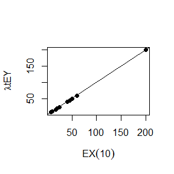

```r
x.mean.es<-rep(0,10)
x.var.es<-rep(0,10)
x.mean.th<-rep(0,10)
x.var.th<-rep(0,10)

for (i in 1:10) {
  p<-poissongamma(sample(1:5,1),sample(1:5,1),sample(1:5,1))
  x.mean.es[i]<-p[1]
  x.var.es[i]<-p[2]
  x.mean.th[i]<-p[3]
  x.var.th[i]<-p[4]
}
plot(x.mean.es,x.mean.th,pch=16,xlab=expression(EX(10)),ylab=expression(lambda*t*EY))
abline(1,1)
```

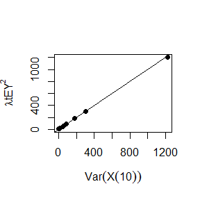

```r
plot(x.var.es,x.var.th,pch=16,xlab=expression(Var(X(10))),ylab=expression(lambda*t*EY^2))
abline(1,1)
```

```r
knitr::kable(cbind(x.mean.es,x.mean.th),digits = 1)
```

| x.mean.es | x.mean.th |
| --- | --- |
| 10.0 | 10.0 |
| 8.0 | 8.0 |
| 24.1 | 24.0 |
| 40.0 | 40.0 |
| 50.4 | 50.0 |
| 199.9 | 200.0 |
| 60.1 | 60.0 |
| 16.7 | 16.7 |
| 45.0 | 45.0 |
| 20.0 | 20.0 |

```r
knitr::kable(cbind(x.var.es,x.var.th),digits = 1)
```

| x.var.es | x.var.th |
| --- | --- |
| 5.2 | 5.0 |
| 8.0 | 8.0 |
| 19.0 | 19.2 |
| 52.9 | 53.3 |
| 303.2 | 300.0 |
| 1221.3 | 1200.0 |
| 180.7 | 180.0 |
| 11.2 | 11.1 |
| 90.0 | 90.0 |
| 50.2 | 50.0 |

From the pictures and tables above the means and the variances estimated of $X(10)$ for several choices of the parameters are accurate compared with the theoretical values.

# 2021-09-30

## Question

Exercises 5.4, 5.9, 5.13, and 5.14 (pages 149-151, Statistical Computating with R).

## Answer

### 5.4

Write a function to compute a Monte Carlo estimate of the $Beta(3, 3)$ cdf, and use the function to estimate $F(x)$ for $x = 0.1, 0.2, \cdots, 0.9$. Compare the estimates with the values returned by the pbeta function in R.

Cdf of $Beta(3,3)$ is
$$\begin{equation}
F(x)=\frac{\int_{0}^{x}u^2(1-u)^2du}{\int_{0}^{1}v^2(1-v)^2dv}.
\end{equation}$$

```r
m<-1e4
F<-function(x){#Monte Carlo estimate of the Beta(3, 3)
  u<-runif(m, min = 0, max = x)#u~U(0,x)
  f1<-mean(x*u*u*(1-u)*(1-u))
  v<-runif(m, min = 0, max = 1)#v~U(0,1)
  f2<-mean(v*v*(1-v)*(1-v))
  return(f1/f2)
}
beta_estimated<-rep(0,9)#Monte Carlo estimate of the Beta(3, 3)
beta_true<-rep(0,9)#values returned by the pbeta function
for (i in 1:9) {
  beta_estimated[i]<-F(0.1*i)
  beta_true[i]<-pbeta(0.1*i,3,3)
}
print(round(cbind(seq(0.1,0.9,0.1),beta_estimated,beta_true),5))
```

```
##           beta_estimated beta_true
##  [1,] 0.1        0.00856   0.00856
##  [2,] 0.2        0.05762   0.05792
##  [3,] 0.3        0.16226   0.16308
##  [4,] 0.4        0.31975   0.31744
##  [5,] 0.5        0.49944   0.50000
##  [6,] 0.6        0.68887   0.68256
##  [7,] 0.7        0.83313   0.83692
##  [8,] 0.8        0.93025   0.94208
##  [9,] 0.9        0.97529   0.99144
```

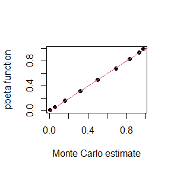

```r
plot(beta_estimated,beta_true,pch=16,xlab = "Monte Carlo estimate",ylab = "pbeta function")
abline(0,1,col=2)
```

From the table and picture above, we can see that Monte Carlo estimate and the values returned by the pbeta function are nearly same.

### 5.9

The Rayleigh density [156, (18.76)] is
$$\begin{equation}
f(x)=\frac{x}{\sigma^2}e^{-x^2/(2\sigma^2)},\qquad x\ge 0,\ \sigma>0.
\end{equation}$$
Implement a function to generate samples from a Rayleigh($\sigma$) distribution, using antithetic variables. What is the percent reduction in variance of $\frac{X+X'}{2}$ compared with $\frac{X_1+X_2}{2}$ for independent $X_1$, $X_2$?

```r
rayleigh<-function(sigma, R=10000, antithetic = TRUE){#inverse transform algorithm
  u<-runif(R/2)#Uniform(0,1)
  if(!antithetic)
    v<-runif(R/2)
  else
    v<-1-u
  x<-(sigma*sqrt(-2*log(1-u))+sigma*sqrt(-2*log(1-v)))/2#(X+X')/2 and (X1+X2)/2
  return(x)
}
sigma<-c(1,3,5,10,20,30)
anti.var<-rep(0,6)#standard deviation using antithetic variables
notanti.var<-rep(0,6)#standard deviation without using antithetic variables
per<-rep(0,6)#percent reduction in variance
for (i in 1:6) {
  anti.var[i]<-var(rayleigh(sigma = sigma[i]))
  notanti.var[i]<-var(rayleigh(sigma = sigma[i], anti= FALSE))
  per[i]<-100*(notanti.var[i]-anti.var[i])/notanti.var[i]
}
print(round(cbind(sigma,anti.var,notanti.var,per),4))
```

```
##      sigma anti.var notanti.var     per
## [1,]     1   0.0110      0.2136 94.8359
## [2,]     3   0.0972      1.9120 94.9177
## [3,]     5   0.3007      5.4898 94.5227
## [4,]    10   1.1762     21.2837 94.4735
## [5,]    20   4.4634     84.6803 94.7292
## [6,]    30   9.6902    199.8810 95.1520
```

### 5.13

Find two importance functions $f_1$ and $f_2$ that are supported on $(1,\infty)$ and are ‘close’ to
$$\begin{equation}
g(x)=\frac{x^2}{\sqrt{2\pi}}e^{-\frac{x^2}{2}},\ x>1.
\end{equation}$$
Which of your two importance functions should produce the smaller variance in estimating
$$\begin{equation}
\int_{1}^{\infty}\frac{x^2}{\sqrt{2\pi}}e^{-\frac{x^2}{2}}dx
\end{equation}$$
by importance sampling? Explain.

The candidates for the importance functions are normal distribution and Rayleigh distribution:
$$\begin{equation}
f_1(x)=\frac{1}{\sqrt{2\pi}}e^{-\frac{x^2}{2}},\ -\infty<x<\infty,
\end{equation}$$
$$\begin{equation}
f_2(x)=xe^{-\frac{x^2}{2}},\ x\ge 0.
\end{equation}$$

```r
m<-100000
theta.hat<-variance<-rep(0,2)
g<-function(x){
  x*x*exp(-x*x/2)*(x>1)/sqrt(2*pi)
}

x<-rnorm(m)#using f1
fg<-g(x)*sqrt(2*pi)/exp(-x*x/2)
theta.hat[1]<-mean(fg)
variance[1]<-var(fg)/m

rayleigh1<-function(sigma, R=10000){#inverse transform algorithm
  u<-runif(R)#Uniform(0,1)
  x<-sigma*sqrt(-2*log(1-u))#generate random samples from the Rayleigh distribution
  return(x)
}
x<-rayleigh1(sigma = 1, R = m)#using f2
fg<-g(x)/(x*exp(-x*x/2))
theta.hat[2]<-mean(fg)
variance[2]<-var(fg)/m
print(cbind(theta.hat=round(theta.hat,4),variance))
```

```
##      theta.hat     variance
## [1,]    0.4034 1.277068e-05
## [2,]    0.3994 1.289674e-06
```

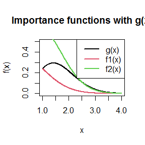

```r
x<-seq(1.01,4,by=0.01)
plot(x,g(x),type = 'l',lwd=2,xlab = "x",ylab = "f(x)",main = "Importance functions with g(x)",ylim = c(0,0.5))
lines(x,exp(-x*x/2)/sqrt(2*pi),col=2,lwd=2)
lines(x,x*exp(-x*x/2),col=3,lwd=2)
legend("topright",legend = c("g(x)","f1(x)","f2(x)"),lwd = 2,col=c(1,2,3))
```

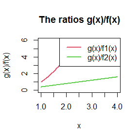

```r
plot(x,g(x)*sqrt(2*pi)/exp(-x*x/2),type = 'l',lwd=2,xlab = "x",ylab = "g(x)/f(x)",main = "The ratios g(x)/f(x)",ylim = c(0,6),col=2)
lines(x,g(x)/(x*exp(-x*x/2)),col=3,lwd=2)
legend("topright",legend = c("g(x)/f1(x)","g(x)/f2(x)"),lwd = 2,col=c(2,3))
```

```r
summary(g(x)*sqrt(2*pi)/exp(-x*x/2))
```

```
##    Min. 1st Qu.  Median    Mean 3rd Qu.    Max.
##   1.020   3.089   6.275   7.025  10.579  16.000
```

```r
summary(g(x)/(x*exp(-x*x/2)))
```

```
##    Min. 1st Qu.  Median    Mean 3rd Qu.    Max.
##  0.4029  0.7011  0.9994  0.9994  1.2976  1.5958
```

From the results above, we can see that when the importance function is Rayleigh distribution, the variance in estimating is smaller. And from the two pictures above, density function of Rayleigh distribution is more approach to $g(x)$ and the ratio $g(x)/f_2(x)$ is nearly constant, so the variance is smaller.

### 5.14

Obtain a Monte Carlo estimate of
$$\begin{equation}
\int_{1}^{\infty}\frac{x^2}{\sqrt{2\pi}}e^{-\frac{x^2}{2}}dx
\end{equation}$$
by importance sampling.

From the question 5.13, we choose the density function of Rayleigh distribution as the importance function.

```r
x<-rayleigh1(sigma = 1, R = m)
fg<-g(x)/(x*exp(-x*x/2))
theta.hat<-mean(fg)
theta.hat
```

```
## [1] 0.3991013
```

# 2021-10-14

## Question

Exercises 6.5 and 6.A (page 180-181, Statistical Computating with R).

If we obtain the powers for two methods under a particular simulation setting with 10,000 experiments: say, 0.651 for one method and 0.676 for another method. We want to know if the powers are different at 0.05 level. (1)What is the corresponding hypothesis test problem? (2)What test should we use? Z-test, two-sample t-test, paired-t test or McNemar test? Why? (3)Please provide the least necessary information for hypothesis testing.

## Answer

### 6.5

T统计量为
$$\begin{equation*}
T=\frac{\sqrt{n}(\bar{X}-\mu)}{S}\sim t_{n-1}
\end{equation*}$$
从而可以得到置信系数为$\alpha$时的对称t-区间为$(\bar{X}-St_{n-1}(\alpha/2)/\sqrt{n},\bar{X}+St_{n-1}(\alpha/2)/\sqrt{n})$。

```r
#卡方分布均值的t-检验
set.seed(1)
n<-20#单次实验的样本量
alpha<-0.05#置信系数
CL<-replicate(1000,expr={
  x<-rchisq(n,df=2)#生成卡方分布随机数
  c(mean(x)-qt(alpha/2,df=n-1)*sd(x)/sqrt(n),mean(x)+qt(alpha/2,df=n-1)*sd(x)/sqrt(n))#计算置信区间
})
s<-0
for (i in 1:1000) {#计算包含真实值的置信区间数量
  if(CL[1,i]>2 & CL[2,i]<2) s<-s+1
}
s/1000#包含真实值的置信区间比例
```

```
## [1] 0.926
```

```r
set.seed(1)
#正态分布的方差检验
n<-20#单次实验的样本量
alpha<-0.05#置信系数
UCL<-replicate(1000,expr={
  x<-rnorm(n,0,2)#生成正态分布随机样本
  (n-1)*var(x)/qchisq(alpha,df=n-1)#计算置信区间
})
mean(UCL>4)#包含真实值的置信区间比例
```

```
## [1] 0.943
```

```r
#卡方分布的方差检验
n<-20#单次实验的样本量
alpha<-0.05#置信系数
UCL<-replicate(1000,expr={
  x<-rchisq(n,df=2)#生成卡方分布随机样本
  (n-1)*var(x)/qchisq(alpha,df=n-1)#计算置信区间
})
mean(UCL>4)#包含真实值的置信区间比例
```

```
## [1] 0.813
```

在检验正态分布方差的实验中，置信区间包含真实值的比例大约是94.3%，与95%非常接近；而在卡方分布方差的实验中，置信区间包含真实值的比例只有81.3%，与95%相差较多。

通过上面的实验与比较，我们可以发现t-区间在偏离正态情况时估计均值要比偏离正态时方差估计区间更为稳健。

### 6.A

取$\alpha=0.05$，令每次实验的样本量为$n=20$。

(1)$\chi^2(1)$:$\mu_0=1$

```r
set.seed(1)
n<-20
alpha<-0.05
mu0<-1#真实均值

m<-10000#实验次数
p<-numeric(m)#储存每次实验的p-value
for (i in 1:m) {
  x<-rchisq(n,df=1)#生成卡方分布样本
  ttest<-t.test(x,alternative="two.sided",mu=mu0)#双边t检验
  p[i]<-ttest$p.value
}
p.hat<-mean(p<alpha)#I型错误率
se.hat<-sqrt(p.hat*(1-p.hat)/m)#估计的标准差
print(c(p.hat,se.hat))
```

```
## [1] 0.100400000 0.003005326
```

(2)$Uniform(0,2)$:$\mu_0=1$

```r
set.seed(1)
n<-20
alpha<-0.05
mu0<-1#真实均值

m<-10000#实验次数
p<-numeric(m)#储存每次实验的p-value
for (i in 1:m) {
  x<-runif(n,min = 0,max = 2)#生成均匀分布样本
  ttest<-t.test(x,alternative="two.sided",mu=mu0)#双边t检验
  p[i]<-ttest$p.value
}
p.hat<-mean(p<alpha)#I型错误率
se.hat<-sqrt(p.hat*(1-p.hat)/m)#估计的标准差
print(c(p.hat,se.hat))
```

```
## [1] 0.050200000 0.002183574
```

(3)$Exponential(1)$:$\mu_0=1$

```r
set.seed(1)
n<-20
alpha<-0.05
mu0<-1#真实均值

m<-10000#实验次数
p<-numeric(m)#储存每次实验的p-value
for (i in 1:m) {
  x<-rexp(n,rate=1)#生成指数分布样本
  ttest<-t.test(x,alternative="two.sided",mu=mu0)#双边t检验
  p[i]<-ttest$p.value
}
p.hat<-mean(p<alpha)#I型错误率
se.hat<-sqrt(p.hat*(1-p.hat)/m)#估计的标准差
print(c(p.hat,se.hat))
```

```
## [1] 0.08120000 0.00273142
```

从上面的实验结果我们可以看出均匀分布的I型错误率是最接近名义显著水平$\alpha=0.05$，而分布$\chi^2(1)$的I型错误率超出名义显著水平最多。由此可见t检验对偏离正态程度较轻时具有稳健性。

### Discussion

If we obtain the powers for two methods under a particular simulation setting with 10,000 experiments: say, 0.651 for one method and 0.676 for another method. We want to know if the powers are different at 0.05 level.

(1)What is the corresponding hypothesis test problem?

令$p_1=$使用第一种方法检验的功效, $p_2=$使用第二种方法的功效，从而我们得到假设检验问题为
$$\begin{equation*}
H_0:p_1=p_2\leftrightarrow H_1:p_1\neq p_2.
\end{equation*}$$

(2)What test should we use? Z-test, two-sample t-test, paired-t test or McNemar test? Why?

Z-test适合大样本时的正态分布样本检验或者近似正态分布样本检验，并且要求数据方差已知；而t-test可以用于小样本检验正态分布或近似正态分布样本，且不需要方差已知。两样本t-test要求两组样本是独立的两组样本，而配对t-test适用于同一组个体进行不同处理后结果的比较。 McNemar test是非参数检验，用于配对计数资料的分析，主要分析配对资料中控制组和处理组的频率或比率是否有差异，只适用于二分变量。由题意，我们是对同一组样本利用两种方法进行处理，所以可以使用配对t-test或者McNemar test。

(3)Please provide the least necessary information for hypothesis testing.

我们需要知道两种方法得到的功效是否已知分布，是否服从正态或者近似正态分布，如果服从正态分布或者近似正态分布，可以使用配对t-test，若是分布未知，且偏离正态分布程度较重，则使用McNemar test。

# 2021-10-21

```r
library(knitr)
library(MASS)
```

## Question

Exercises 6.C (pages 182, Statistical Computating with R).

Repeat Examples 6.8 and 6.10 for Mardia’s multivariate skewness test. Mardia [187] proposed tests of multivariate normality based on multivariate generalizations of skewness and kurtosis. If $X$ and $Y$ are iid, the multivariate population skewness $\beta_{1,d}$ is defined by Mardia as
$$\begin{equation*}
\beta_{1,d}=E[(X-\mu)^{T}\Sigma^{-1}(Y-\mu)]^3.
\end{equation*}$$
Under normality, $\beta_{1,d}=0$. The multivariate skewness statistic is
$$\begin{equation*}
b_{1,d}=\frac{1}{n^2}\sum^{n}_{i,j=1}((X_i-\bar{X})^T\hat{\Sigma}^{-1}(X_j-\bar{X}))^3,
\end{equation*}$$
where $\hat{\Sigma}$ is the maximum likelihood estimator of covariance. Large values of $b_{1,d}$ are significant. The asymptotic distribution of $nb_{1,d}/6$ is chisquared with $d(d+1)(d+2)/6$ degrees of freedom.

## Answer

先考虑例6.8中的实验。先计算正态偏度检验的I型错误率，取置信系数$\alpha=0.05$，利用统计量$b_{1,d}$的渐近分布$\chi^2(d(d+1)(d+2)/6)$，样本数量$n=10,20,30,50,100,500$。

卡方分布下样本数量不同情况时的$b_{1,d}$临界值计算，其中样本维数$d=3$：

```r
cv.n<-function(d){#样本数量不同时临界值的计算，其中d为数据维度
  n<-c(10,20,30,50,100,500)#样本数量
  cv<-6*qchisq(0.95,df=d*(d+1)*(d+2)/6)/n#不同样本数量下的临界值
  return(cv)
}
d<-3
cv<-cv.n(3)
knitr::kable(rbind(c("n",10,20,30,50,100,500),c("cv",round(cv,4))))
```

| n | 10 | 20 | 30 | 50 | 100 | 500 |
| --- | --- | --- | --- | --- | --- | --- |
| cv | 10.9842 | 5.4921 | 3.6614 | 2.1968 | 1.0984 | 0.2197 |

接下来计算偏度统计量:

```r
sk<-function(x){#计算样本X偏度统计量的函数b_{1,d}
  n<-ncol(x)#样本数量
  d<-nrow(x)#样本的数据维度
  xbar<-rowMeans(x)#样本的均值
  xcov<-cov(t(x-xbar))#样本的协方差阵
  x.cen<-x-xbar#样本数据中心化
  return(sum((t(x.cen)%*%solve(xcov)%*%x.cen)^3)/n/n)#输出偏度统计量的函数b_{1,d}
}
```

```r
n<-c(10,30,50,100,500)
p.reject<-rep(0,length(n))#储存不同样本数量下拒接原假设的概率
m<-500#每个样本数据下的实验次数
d<-3
for (i in 1:length(n)) {
  sktests<-rep(0,m)
  for (j in 1:m) {
    x<-t(as.matrix(mvrnorm(n=n[i],mu=c(0,0,0),Sigma=matrix(c(3,2,1,2,3,2,1,2,3),3,3))))#生成n[i]个样本
    sktests[j]<-as.integer(abs(sk(x))>=cv[i])
  }
  p.reject[i]<-mean(sktests)#拒绝原假设的概率
}
p.reject
```

```
## [1] 0.000 0.000 0.000 0.002 0.000
```

```r
knitr::kable(rbind(c("n",10,30,50,100,500),c("p.reject",round(p.reject,4))))
```

| n | 10 | 30 | 50 | 100 | 500 |
| --- | --- | --- | --- | --- | --- |
| p.reject | 0 | 0 | 0 | 0.002 | 0 |

再考虑例6.10中的实验，考虑污染的正态分布
$$\begin{equation*}
(1-\epsilon)N(0,S_1)+\epsilon N(0,S_2),\ 0\le\epsilon\le1.
\end{equation*}$$
其中
$$\begin{equation*}
S_1=\left(
\begin{array}{ccc}
10 & 2 & 1\\
2 & 10 & 2\\
1 & 2 & 10\\
\end{array}
\right),\ S_2=\left(
\begin{array}{ccc}
1 & 0 & 0\\
0 & 1 & 0\\
0 & 0 & 1\\
\end{array}
\right).
\end{equation*}$$
取$\alpha=0.1,\ n=100$。

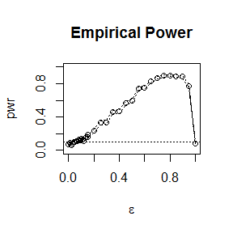

```r
alpha<-0.1#置信系数
n<-100#样本数量
m<-500#实验次数
epsilon<-c(seq(0,0.15,0.01),seq(0.15,1,0.05))
N<-length(epsilon)
pwr<-rep(0,N)#功效
cv<-6*qchisq(1-alpha,df=d*(d+1)*(d+2)/6)/n#临界值
s1<-matrix(c(10,2,1,2,10,2,1,2,10),3,3)
s2<-matrix(c(3,2,1,2,3,2,1,2,3),3,3)
x<-matrix(0,nrow=3,ncol=n)

for (j in 1:N) {
  e<-epsilon[j]
  sktests<-rep(0,m)
  for (i in 1:m) {
    for (k in 1:n) {#生成污染的正态分布样本
      t<-sample(c(1,2),1,prob = c(1-e,e))
      if(t==1) x[,k]<-mvrnorm(1,mu=c(0,0,0),Sigma=s1)
      else x[,k]<-mvrnorm(1,mu=c(0,0,0),Sigma=s2)
    }
    sktests[i]<-as.integer(abs(sk(x))>=cv)
  }
  pwr[j]<-mean(sktests)
}

plot(epsilon,pwr,type="b",xlab = bquote(epsilon),ylim = c(0,1),main="Empirical Power")#绘制功效-epsilon图
abline(h=0.1,lty=3)
se<-sqrt(pwr*(1-pwr)/m)#标准差
lines(epsilon,pwr+se,lty=3)
lines(epsilon,pwr-se,lty=3)
```

由以上结果可以看出，当$\epsilon=0$或$\epsilon=1$时也即样本服从多元正态分布时，功效曲线在水平线$\alpha=0.1$附近。而$0<\epsilon<1$时功效曲线位于水平线上方，也即拒绝原假设的概率大于0.10，其中经验功效大约在$\epsilon=0.8$时达到最大。

# 2021-10-28

```r
library(bootstrap)
data(scor,package = "bootstrap")
library(boot)
library(knitr)
```

## Question

Exercises 7.7, 7.8, 7.9, and 7.B (pages 213, Statistical Computating with R).

## Answer

### 7.7

```r
set.seed(1)
#样本估计
lambda.hat<-sort(eigen(cov(scor))$values,decreasing = T)#求解协方差矩阵的MLE估计矩阵的特征值并按降序排列
theta.hat<-lambda.hat[1]/sum(lambda.hat)#样本估计

n<-nrow(scor)
B<-2000
theta.b<-rep(0,B)

for (b in 1:B) {#bootstrap
  i<-sample(1:n,size=n,replace = TRUE)
  lambda.b<-sort(eigen(cov(scor[i,]))$values,decreasing = T)
  theta.b[b]<-lambda.b[1]/sum(lambda.b)
}
bias<-mean(theta.b)-theta.hat#偏差
se<-sd(theta.b)#标准差
print(list(theta.hat=theta.hat,bias=bias,se=se))
```

```
## $theta.hat
## [1] 0.619115
##
## $bias
## [1] 0.0001943598
##
## $se
## [1] 0.04611542
```

### 7.8

```r
#jackknife
theta.jack<-rep(0,n)
for (i in 1:n) {
  lambda.jack<-sort(eigen(cov(scor[-i,]))$values,decreasing = T)
  theta.jack[i]<-lambda.jack[1]/sum(lambda.jack)
}
bias<-(n-1)*(mean(theta.jack)-theta.hat)#偏差
se<-sqrt(n-1)*mean((theta.jack-mean(theta.jack))^2)#标准差
print(list(theta.hat=theta.hat,bias=bias,se=se))
```

```
## $theta.hat
## [1] 0.619115
##
## $bias
## [1] 0.001069139
##
## $se
## [1] 0.0002632499
```

### 7.9

```r
stat<-function(dat,index){#参数statistic
  lambda<-sort(eigen(cov(dat[index,]))$values,decreasing = T)
  lambda[1]/sum(lambda)
}
boot.obj<-boot(scor,statistic = stat,R=2000)#bootstrap
ci<-boot.ci(boot.obj,type=c("perc","bca"))#计算percentile和BCa置信区间
knitr::kable(rbind(c("precent",ci$perc[4],ci$perc[5]),c("BCa",ci$bca[4],ci$bca[5])),digits = 4)
```

| precent | 0.516278859066827 | 0.708649069662076 |
| --- | --- | --- |
| BCa | 0.513745105506653 | 0.704789252691748 |

从而得到95%的BCa置信区间为(0.5137,0.7048)。

### 7.B

取置信系数$\alpha=0.05$，随机变量$X$的偏度$\sqrt{\beta_1}$定义为
$$\begin{equation*}
\sqrt{\beta_1}=\frac{E[(X-\mu_X)]^3}{\sigma_X^3}，
\end{equation*}$$
其中$\mu_X=E[X],\ \sigma_X^2=Var(X)$。假设为
$$\begin{equation*}
H_0:\sqrt{\beta_1}=0\leftrightarrow H_1:\sqrt{\beta_1}\neq0.
\end{equation*}$$
样本估计量为
$$\begin{equation*}
\sqrt{b_1}=\frac{\frac{1}{n}\sum^{n}_{i=1}(X_i-\bar{X})^3}{(\frac{1}{n}\sum^{n}_{i=1}(X_i-\bar{X})^2)^{3/2}}.
\end{equation*}$$

```r
sk<-function(x,index){
  xbar<-mean(x[index])
  m3<-mean((x[index]-xbar)^3)
  m2<-mean((x[index]-xbar)^2)
  m3/m2^1.5
}
```

对于正态分布的样本,我们可以知晓偏度系数的真实值为0，在下面的实验中，随机选取一个正态分布样本计算偏度系数，进行蒙特卡洛实验算出bootstrap区间覆盖样本偏度系数的概率以及覆盖真实偏度系数的概率。

```r
set.seed(1)
m<-1000#蒙特卡洛实验次数
x<-rnorm(10000)#正态样本
sk.x<-mean((x-mean(x))^3)/(mean((x-mean(x))^2))^1.5#计算样本的偏度系数
sk.x
```

```
## [1] -0.02347698
```

```r
sktests<-matrix(0,nrow=6,ncol=m)
sk.true<-matrix(0,nrow=6,ncol=m)
for (j in 1:m) {#进行蒙特卡洛实验
  x<-rnorm(1000)
  #bootstrap
  boot.obj<-boot(x,statistic = sk,R=100)
  b<-boot.ci(boot.obj,type = c("norm", "basic", "perc"))
  sktests[1,j]<-as.integer(sk.x<=b$normal[2])#样本偏度系数normal检验落入左侧
  sktests[2,j]<-as.integer(sk.x>=b$normal[3])#样本偏度系数normal检验落入右侧
  sktests[3,j]<-as.integer(sk.x<=b$basic[4])#样本偏度系数basic检验落入左侧
  sktests[4,j]<-as.integer(sk.x>=b$basic[5])#样本偏度系数basic检验落入右侧
  sktests[5,j]<-as.integer(sk.x<=b$percent[4])#样本偏度系数percent检验落入左侧
  sktests[6,j]<-as.integer(sk.x>=b$percent[5])#样本偏度系数percent检验落入右侧

  sk.true[1,j]<-as.integer(0<=b$normal[2])#真实偏度系数normal检验落入左侧
  sk.true[2,j]<-as.integer(0>=b$normal[3])#真实偏度系数normal检验落入右侧
  sk.true[3,j]<-as.integer(0<=b$basic[4])#真实偏度系数basic检验落入左侧
  sk.true[4,j]<-as.integer(0>=b$basic[5])#真实偏度系数basic检验落入右侧
  sk.true[5,j]<-as.integer(0<=b$percent[4])#真实偏度系数percent检验落入左侧
  sk.true[6,j]<-as.integer(0>=b$percent[5])#真实偏度系数percent检验落入右侧
}
samplesk<-rowMeans(sktests)
truesk<-rowMeans(sk.true)
cat("样本偏度系数")
```

```
## 样本偏度系数
```

```r
knitr::kable(rbind(c("type","miss on the left","miss on the right","coverage rate"),c("normal",samplesk[1:2],1-sum(samplesk[1:2])),c("basic",samplesk[3:4],1-sum(samplesk[3:4])),c("percet",samplesk[5:6],1-sum(samplesk[5:6]))))
```

| type | miss on the left | miss on the right | coverage rate |
| --- | --- | --- | --- |
| normal | 0.049 | 0.015 | 0.936 |
| basic | 0.044 | 0.013 | 0.943 |
| percet | 0.04 | 0.017 | 0.943 |

```r
cat("真实偏度系数")
```

```
## 真实偏度系数
```

```r
knitr::kable(rbind(c("type","miss on the left","miss on the right","coverage rate"),c("normal",truesk[1:2],1-sum(truesk[1:2])),c("basic",truesk[3:4],1-sum(truesk[3:4])),c("percet",truesk[5:6],1-sum(truesk[5:6]))))
```

| type | miss on the left | miss on the right | coverage rate |
| --- | --- | --- | --- |
| normal | 0.026 | 0.036 | 0.938 |
| basic | 0.024 | 0.034 | 0.942 |
| percet | 0.017 | 0.031 | 0.952 |

可以看到用bootstrap得到的置信区间包含真实偏度系数的概率接近0.95，且真实值落入区间左侧和右侧的概率接近0.025，对于从正态分布得到的样本，则存在误差。

而对于卡方分布的样本,我们可以知晓$\chi^2(5)$偏度系数的真实值为1.265，在下面的实验中，随机选取一个卡方分布样本计算偏度系数，进行蒙特卡洛实验算出bootstrap区间覆盖样本偏度系数的概率以及覆盖真实偏度系数的概率。

```r
set.seed(1)
m<-1000#蒙特卡洛实验次数
x<-rchisq(10000,df=5)#正态样本
sk.x<-mean((x-mean(x))^3)/(mean((x-mean(x))^2))^1.5#计算样本的偏度系数
sk.x
```

```
## [1] 1.197984
```

```r
sktests<-matrix(0,nrow=6,ncol=m)
sk.true<-matrix(0,nrow=6,ncol=m)
for (j in 1:m) {#进行蒙特卡洛实验
  x<-rchisq(1000,df=5)
  #bootstrap
  boot.obj<-boot(x,statistic = sk,R=100)
  b<-boot.ci(boot.obj,type = c("norm", "basic", "perc"))
  sktests[1,j]<-as.integer(sk.x<=b$normal[2])#样本偏度系数normal检验落入左侧
  sktests[2,j]<-as.integer(sk.x>=b$normal[3])#样本偏度系数normal检验落入右侧
  sktests[3,j]<-as.integer(sk.x<=b$basic[4])#样本偏度系数basic检验落入左侧
  sktests[4,j]<-as.integer(sk.x>=b$basic[5])#样本偏度系数basic检验落入右侧
  sktests[5,j]<-as.integer(sk.x<=b$percent[4])#样本偏度系数percent检验落入左侧
  sktests[6,j]<-as.integer(sk.x>=b$percent[5])#样本偏度系数percent检验落入右侧

  sk.true[1,j]<-as.integer(1.265<=b$normal[2])#真实偏度系数normal检验落入左侧
  sk.true[2,j]<-as.integer(1.265>=b$normal[3])#真实偏度系数normal检验落入右侧
  sk.true[3,j]<-as.integer(1.265<=b$basic[4])#真实偏度系数basic检验落入左侧
  sk.true[4,j]<-as.integer(1.265>=b$basic[5])#真实偏度系数basic检验落入右侧
  sk.true[5,j]<-as.integer(1.265<=b$percent[4])#真实偏度系数percent检验落入左侧
  sk.true[6,j]<-as.integer(1.265>=b$percent[5])#真实偏度系数percent检验落入右侧
}
samplesk<-rowMeans(sktests)
truesk<-rowMeans(sk.true)
cat("样本偏度系数")
```

```
## 样本偏度系数
```

```r
knitr::kable(rbind(c("type","miss on the left","miss on the right","coverage rate"),c("normal",samplesk[1:2],1-sum(samplesk[1:2])),c("basic",samplesk[3:4],1-sum(samplesk[3:4])),c("percet",samplesk[5:6],1-sum(samplesk[5:6]))))
```

| type | miss on the left | miss on the right | coverage rate |
| --- | --- | --- | --- |
| normal | 0.039 | 0.046 | 0.915 |
| basic | 0.036 | 0.046 | 0.918 |
| percet | 0.027 | 0.044 | 0.929 |

```r
cat("真实偏度系数")
```

```
## 真实偏度系数
```

```r
knitr::kable(rbind(c("type","miss on the left","miss on the right","coverage rate"),c("normal",truesk[1:2],1-sum(truesk[1:2])),c("basic",truesk[3:4],1-sum(truesk[3:4])),c("percet",truesk[5:6],1-sum(truesk[5:6]))))
```

| type | miss on the left | miss on the right | coverage rate |
| --- | --- | --- | --- |
| normal | 0.01 | 0.118 | 0.872 |
| basic | 0.01 | 0.112 | 0.878 |
| percet | 0.006 | 0.125 | 0.869 |

从上述结果可以看出，无论是真实值还是样本值，误差都比较大，且落入区间左右两侧的概率也不接近。

# 2021-11-04

```r
library(knitr)
library(MASS)
library(boot)
library(RANN)
library(energy)
library(Ball)
```

## Question

Exercise 8.2 (page 242, Statistical Computating with R).

Design experiments for evaluating the performance of the NN, energy, and ball methods in various situations. i. Unequal variances and equal expectations ii. Unequal variances and unequal expectations iii. Non-normal distributions: t distribution with 1 df (heavy-tailed distribution), bimodel distribution (mixture of two normal distributions) iv. Unbalanced samples (say, 1 case versus 10 controls) Note: The parameters should be chosen such that the powers are distinguishable (say, range from 0.3 to 0.8).

## Answer

### 8.2

我们选择每次重排检验得到的p值作为统计量，p值越大越支持原假设也即X与Y独立，p值越小越支持对立假设，因此ASL为
$$\begin{equation}
\hat{p}=\frac{1+\#\{\hat{p}^{(b)}\le \hat{p}_0\}}{B+1}.
\end{equation}$$
此时若$\hat{p}<\alpha$拒绝$H_0$。

先随机生成两组独立数据X和Y。

```r
set.seed(1)
x<-mvrnorm(100,c(0,0),Sigma = matrix(c(2,1,1,2),2,2))
y<-mvrnorm(100,c(0,0),Sigma = diag(2))
```

再利用重排法：

```r
spear<-function(z,ix){
  #dims是x和y的维度
  x<-z[,1:2]#x不改变
  y<-z[ix,3:4]#重排y的行
  return(cor.test(x,y,method = "spearman")$p.value)
}

z<-cbind(x,y)
boot.obj<-boot(data=z,statistic = spear,R=999,sim="permutation")
tb<-c(boot.obj$t0,boot.obj$t)
mean(tb<=boot.obj$t0)
```

```
## [1] 0.678
```

显著性水平为0.678，大于$\alpha=0.05$时接受原假设即X与Y独立。

再生成两组不独立数据X和Y。

```r
x<-mvrnorm(100,c(0,0),Sigma = diag(2))
y<-x
```

再利用重排法：

```r
spear<-function(z,ix){
  #dims是x和y的维度
  x<-z[,1:2]#x不改变
  y<-z[ix,3:4]#重排y的行
  return(cor.test(x,y,method = "spearman")$p.value)
}
z<-cbind(x,y)
boot.obj<-boot(data=z,statistic = spear,R=999,sim="permutation")
tb<-c(boot.obj$t0,boot.obj$t)
mean(tb<=boot.obj$t0)
```

```
## [1] 0.001
```

显著性水平为0.001，小于$\alpha=0.05$，拒绝原假设认为X与Y不独立。

### 附加题

Design experiments for evaluating the performance of the NN, energy, and ball methods in various situations.

```r
Tn<-function(z,ix,sizes,k){#进行NN的统计量计算
  n1<-sizes[1]
  n2<-sizes[2]
  n<-n1+n2
  if(is.vector(z)) z<-data.frame(z,0)#确保z不是向量以保证以下代码的正确性
  z<-z[ix,]
  NN<-nn2(data=z,k=k+1)#NN
  block1<-NN$nn.idx[1:n1,-1]#寻找前n1个邻居
  block2<-NN$nn.idx[(n1+1):n,-1]#寻找后n2个邻居
  i1<-sum(block1<n1+0.5)
  i2<-sum(block2>n1+0.5)
  (i1+i2)/(k*n)
}

eqdist.nn<-function(z,sizes,k){
  boot.obj<-boot(data=z,statistic = Tn,R=R,sim="permutation",sizes=sizes,k=k)#重排法
  ts<-c(boot.obj$t0,boot.obj$t)
  p.value<-mean(ts>=ts[1])
  list(statistic=ts[1],p.value=p.value)
}
```

1. Unequal variances and equal expectations

```r
m<-200
k<-3
p<-2#数据维度
set.seed(1)
n1<-n2<-50#样本数量
R<-100
n<-n1+n2
N<-c(n1,n2)

p.values<-matrix(0,m,3)
for (i in 1:m) {
  x<-mvrnorm(n1,c(0,0),diag(2))
  y<-mvrnorm(n2,c(0,0),diag(2,2))
  z<-rbind(x,y)
  p.values[i,1] <- eqdist.nn(z,N,k)$p.value#NN
  p.values[i,2] <- eqdist.etest(z,sizes=N,R=R)$p.value#ENERGY
  p.values[i,3] <- bd.test(x=x,y=y,num.permutations=R,seed=i*1)$p.value#BALL
}
alpha<-0.1
pow<-colMeans(p.values<alpha)
pow
```

```
## [1] 0.355 0.465 0.845
```

```r
alpha<-0.05
pow<-colMeans(p.values<alpha)
pow
```

```
## [1] 0.235 0.300 0.745
```

可以看出Ball test是表现最好的，其次是energy test。

2. Unequal variances and unequal expectations

```r
m<-200
k<-3
p<-2#数据维度
set.seed(1)
n1<-n2<-50#样本数量
R<-100
n<-n1+n2
N<-c(n1,n2)

p.values<-matrix(0,m,3)
for (i in 1:m) {
  x<-mvrnorm(n1,c(0,0),diag(2))
  y<-mvrnorm(n2,c(1,1),diag(2,2))
  z<-rbind(x,y)
  p.values[i,1] <- eqdist.nn(z,N,k)$p.value#NN
  p.values[i,2] <- eqdist.etest(z,sizes=N,R=R)$p.value#ENERGY
  p.values[i,3] <- bd.test(x=x,y=y,num.permutations=R,seed=i*1)$p.value#BALL
}

alpha<-0.05
pow<-colMeans(p.values<alpha)
pow
```

```
## [1] 0.95 1.00 1.00
```

```r
alpha<-0.005
pow<-colMeans(p.values<alpha)
pow
```

```
## [1] 0 0 0
```

Ball test和energy test的表现明显比NN好。

3. Non-normal distributions: t distribution with 1 df (heavy-tailed distribution), bimodel distribution (mixture of two normal distributions)

考虑t正态分布X和混合正态分布Y，$X\sim t(1),Y\sim 0.3N(0,1)+0.7N(3,2)$。

```r
m<-200
k<-3
p<-2#数据维度
set.seed(1)
n1<-n2<-50#样本数量
R<-100
n<-n1+n2
N<-c(n1,n2)

p.values<-matrix(0,m,3)
for (i in 1:m) {
  x<-as.matrix(rt(n1,df=1))
  s1<-rbinom(1,n2,0.3)
  s2<-n2-s1
  y1<-rnorm(s1,0,1)
  y2<-rnorm(s2,3,2)
  y<-c(y1,y2)
  y<-matrix(y)
  z<-rbind(x,y)
  p.values[i,1] <- eqdist.nn(z,N,k)$p.value#NN
  p.values[i,2] <- eqdist.etest(z,sizes=N,R=R)$p.value#ENERGY
  p.values[i,3] <- bd.test(x=x,y=y,num.permutations=R,seed=i*1)$p.value#BALL
}
alpha<-0.05
pow<-colMeans(p.values<alpha)
pow
```

```
## [1] 0.835 1.000 0.990
```

```r
alpha<-0.01
pow<-colMeans(p.values<alpha)
pow
```

```
## [1] 0.560 0.940 0.895
```

Ball test和energy test的表现明显比NN好。

4. Unbalanced samples (say, 1 case versus 10 controls)

```r
m<-100
k<-3
p<-2#数据维度
set.seed(1)
n1<-10
n2<-90#样本数量
R<-100
n<-n1+n2
N<-c(n1,n2)

p.values<-matrix(0,m,3)
for (i in 1:m) {
  x<-mvrnorm(n1,c(0,0),diag(2))
  y<-mvrnorm(n2,c(0,0),diag(2,2))
  z<-rbind(x,y)
  p.values[i,1] <- eqdist.nn(z,N,k)$p.value#NN
  p.values[i,2] <- eqdist.etest(z,sizes=N,R=R)$p.value#ENERGY
  p.values[i,3] <- bd.test(x=x,y=y,num.permutations=R,seed=i*1)$p.value#BALL
}
alpha<-0.1
pow<-colMeans(p.values<alpha)
pow
```

```
## [1] 0.12 0.07 0.52
```

```r
alpha<-0.05
pow<-colMeans(p.values<alpha)
pow
```

```
## [1] 0.08 0.04 0.37
```

Ball test表现最好。

考虑t正态分布X和混合正态分布Y，$X\sim t(1),Y\sim 0.3N(0,1)+0.7N(3,2)$，且二者数据量差很多。

```r
m<-200
k<-3
p<-2#数据维度
set.seed(1)
n1<-10
n2<-90#样本数量
R<-100
n<-n1+n2
N<-c(n1,n2)

p.values<-matrix(0,m,3)
for (i in 1:m) {
  x<-as.matrix(rt(n1,df=1))
  s1<-rbinom(1,n2,0.3)
  s2<-n2-s1
  y1<-rnorm(s1,0,1)
  y2<-rnorm(s2,3,2)
  y<-c(y1,y2)
  y<-matrix(y)
  z<-rbind(x,y)
  p.values[i,1] <- eqdist.nn(z,N,k)$p.value#NN
  p.values[i,2] <- eqdist.etest(z,sizes=N,R=R)$p.value#ENERGY
  p.values[i,3] <- bd.test(x=x,y=y,num.permutations=R,seed=i*1)$p.value#BALL
}
alpha<-0.1
pow<-colMeans(p.values<alpha)
pow
```

```
## [1] 0.455 0.910 0.705
```

```r
alpha<-0.05
pow<-colMeans(p.values<alpha)
pow
```

```
## [1] 0.345 0.795 0.575
```

energy test的表现最好，NN表现最差。

# 2021-11-11

```r
library(knitr)
library(coda)
```

## Question

Exercies 9.3 and 9.8 (pages 277-278, Statistical Computating with R).

For each of the above exercise, use the Gelman-Rubin method to monitor convergence of the chain, and run the chain until it converges approximately to the target distribution according to $\hat{R}<1.2$.

## Answer

### 9.3

取正态分布$N(X_t,\sigma^2)$作为提议分布，丢弃链的前1000个迭代值。

```r
set.seed(123)
#标准柯西分布的密度函数
f<-function(x){
  return(1/(pi*(1+x^2)))
}

#生成标准柯西分布的马尔科夫链
cauchy.chain<-function(sigma,N,X1){
  #sigma为提议分布的标准差
  #N为链的长度
  #初始值为X1
  x<-rep(0,N)
  x[1]<-X1
  u<-runif(N)

  for (i in 2:N) {
    xt<-x[i-1]
    y<-rnorm(1,xt,sigma)
    num<-f(y)*dnorm(xt,y,sigma)
    den<-f(xt)*dnorm(y,xt,sigma)
    r<-num/den
    if(u[i]<=r) x[i]<-y
    else x[i]<-xt
  }
  return(x)
}

#Gelman-Rubin method
gelman.rubin<-function(psi){
  psi<-as.matrix(psi)
  n<-ncol(psi)
  k<-nrow(psi)

  psi.means<-rowMeans(psi)
  B<-n*var(psi.means)
  psi.w<-apply(psi,1,"var")
  W<-mean(psi.w)
  v.hat<-W*(n-1)/n+(B/n)
  r.hat<-v.hat/W
  return(r.hat)
}

sigma<-1#提议分布的标准差
n<-11000#链的长度
b<-1000#预烧期值

X<-cauchy.chain(sigma,n,0)
X<-X[-(1:b)]
```

```r
#实验生成的随机数与真实Cauchy分布分位数的比较
a<-0.1*c(1:9)
knitr::kable(rbind(c("generated observations",round(quantile(X,a),4)),c("standard Cauchy distribution",round(qcauchy(a),4))))
```

|  | 10% | 20% | 30% | 40% | 50% | 60% | 70% | 80% | 90% |
| --- | --- | --- | --- | --- | --- | --- | --- | --- | --- |
| generated observations | -2.6134 | -1.2886 | -0.6883 | -0.3267 | -0.0206 | 0.2944 | 0.6331 | 1.1334 | 2.1907 |
| standard Cauchy distribution | -3.0777 | -1.3764 | -0.7265 | -0.3249 | 0 | 0.3249 | 0.7265 | 1.3764 | 3.0777 |

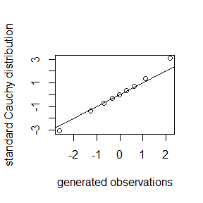

```r
plot(quantile(X,a),qcauchy(a),type="p",xlab = "generated observations",ylab = "standard Cauchy distribution")
abline(a=0,b=1)
```

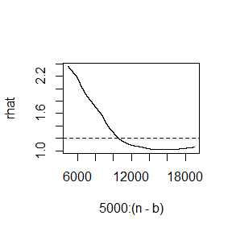

```r
set.seed(1)
sigma<-1#提议分布的标准差
k<-4#生成的马尔可夫链数目
n<-20000#链的长度
b<-1000#预烧期值

#生成链
X<-matrix(0,nrow=k,ncol=n-b)
for (i in 1:k) {
  X[i,]<-cauchy.chain(sigma,n,0)[-c(1:b)]#去掉前1000个迭代值
}
psi<-t(apply(X,1,cumsum))
for (i in 1:nrow(psi)) {
  psi[i,]<-psi[i,]/(1:ncol(psi))
}

rhat<-rep(0,n-b)
for(j in 5000:(n-b)){
  rhat[j]<-gelman.rubin(psi[,1:j])#从链长度为5000时开始计算
}
rhat<-rhat[5000:(n-b)]
plot(5000:(n-b),rhat,type="l")
abline(h=1.2,lty=2)
```

```r
which(rhat<=1.2)[1]+5000
```

```
## [1] 10576
```

若是改变实验中提议分布的标准差：

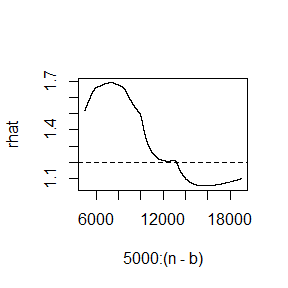

```r
set.seed(1)
sigma<-3#提议分布的标准差
k<-4#生成的马尔可夫链数目
n<-20000#链的长度
b<-1000#预烧期值

#生成链
X<-matrix(0,nrow=k,ncol=n-b)
for (i in 1:k) {
  X[i,]<-cauchy.chain(sigma,n,0)[-c(1:b)]#去掉前1000个迭代值
}
psi<-t(apply(X,1,cumsum))
for (i in 1:nrow(psi)) {
  psi[i,]<-psi[i,]/(1:ncol(psi))
}

rhat<-rep(0,n-b)
for(j in 5000:(n-b)){
  rhat[j]<-gelman.rubin(psi[,1:j])#从链长度为5000时开始计算
}
rhat<-rhat[5000:(n-b)]
plot(5000:(n-b),rhat,type="l")
abline(h=1.2,lty=2)
```

```r
which(rhat<=1.2)[1]+5000
```

```
## [1] 13173
```

从上述实验结果，在去掉链的前1000个迭代之后，大约在13173以后$\hat{R}<1.2$。

### 9.8

```r
N<-10000#链的长度
burn<-1000#预烧期值


#生成二元的马尔可夫链
chain<-function(n,a,b,N,X1){
  set.seed(1)
  #sigma为提议分布的标准差
  #N为链的长度
  #初始值为X1
  X<-matrix(0,N,2)#马尔可夫链
  X[1,]<-X1


  for (i in 2:N) {
    y<-X[i-1,2]
    x<-X[i,1]<-rbinom(1,n,prob = y)
    X[i,2]<-rbeta(1,shape1=x+a,shape2=n-x+b)
  }
  return(X[(burn+1):N,])
}
```

参数$n=19$:

```r
set.seed(1)
n<-19
a<-1
b<-1
#更改初始值
x1<-sample(1:n,1)
y1<-runif(1)
X1<-c(x1,y1)
x2<-sample(1:n,1)
y2<-runif(1)
X2<-c(x2,y2)
x3<-sample(1:n,1)
y3<-runif(1)
X3<-c(x3,y3)

#生成三个初始值不同的马尔可夫链
X<-list(chain(n,a,b,N,X1),chain(n,a,b,N,X2),chain(n,a,b,N,X3))
#Gelman-Rubin诊断
mcmc<-mcmc.list(mcmc(X[[1]]),mcmc(X[[2]]),mcmc(X[[3]]))
gelman.diag(mcmc,transform = T)
```

```
## Potential scale reduction factors:
##
##      Point est. Upper C.I.
## [1,]          1       1.01
## [2,]          1       1.02
##
## Multivariate psrf
##
## 1.01
```

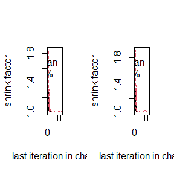

```r
gelman.plot(mcmc,transform = T)
```

可以看出大概在1000以内$\hat{R}<1.2$.

更改参数$n=5$：

```r
set.seed(1)
n<-5
a<-1
b<-1
#更改初始值
x1<-sample(1:n,1)
y1<-runif(1)
X1<-c(x1,y1)
x2<-sample(1:n,1)
y2<-runif(1)
X2<-c(x2,y2)
x3<-sample(1:n,1)
y3<-runif(1)
X3<-c(x3,y3)

#生成三个初始值不同的马尔可夫链
X<-list(chain(n,a,b,N,X1),chain(n,a,b,N,X2),chain(n,a,b,N,X3))
#Gelman-Rubin诊断
mcmc<-mcmc.list(mcmc(X[[1]]),mcmc(X[[2]]),mcmc(X[[3]]))
gelman.diag(mcmc,transform = T)
```

```
## Potential scale reduction factors:
##
##      Point est. Upper C.I.
## [1,]          1          1
## [2,]          1          1
##
## Multivariate psrf
##
## 1
```

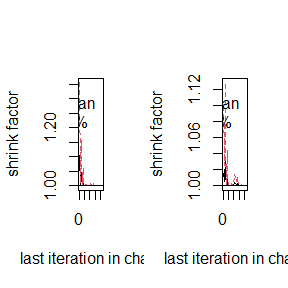

```r
gelman.plot(mcmc,transform = T)
```

当$n$从19变到5时，收敛变快了。$n=5$时，初始的$\hat{R}<1.2$。

# 2021-11-18

## Question

Exercises 11.3 and 11.5 (pages 353-354, Statistical Computing with R)

Suppose $T_1,\cdots,T_n$ are i.i.d. samples drawn from the exponential distribution with expectation $\lambda$. Those values greater than $\tau$ are not observed due to right censorship, so that the observed values are $Y_i=T_iI(T_i\le\tau)+\tau I(T_i>\tau),\ i=1,\cdots,n$. Suppose $\tau=1$ and the observed $Y_i$ values are as follows: 0.54, 0.48, 0.33, 0.43, 1.00, 1.00, 0.91, 1.00, 0.21, 0.85 Use the E-M algorithm to estimate $\lambda$, compare your result with the observed data MLE (note: $Y_i$ follows a mixture distribution).

## Answer

### 11.3

1. $$\begin{equation*}
   \frac{(-1)^k}{k!2^k}\frac{\Vert a\Vert^{2k+2}}{(2k+1)(2k+2)}\frac{\Gamma(\frac{d+1}{2})\Gamma(k+\frac{3}{2})}{\Gamma(k+\frac{d}{2}+1)}=(-1)^k exp\{-\ln k!-k\ln 2+(k+1)\ln \Vert a\Vert^{2}-\ln (2k+1)-\ln (2k+2)+\ln \Gamma(\frac{d+1}{2})+\ln \Gamma(k+\frac{3}{2})-\ln\Gamma(k+\frac{d}{2}+1)\}.
   \end{equation*}$$

```r
#计算第k项的值
k.term<-function(k,a,d){
  #k>=0,d>0整数，a是一个d维向量
  (-1)^k*exp(-log(factorial(k)) - k*log(2) + (k+1)*log(sum(a^2)) - log(2*k+1) - log(2*k+2) + lgamma((d+1)/2) + lgamma(k+1.5) - lgamma(k+(d/2)+1))
}
```

```r
#计算求和
k.sum<-function(a,d){
  #d>0整数，a是一个d维向量
  s<-0
  kterm<-1
  k<-0
  while (k<=1000 & abs(kterm)>10e-10) {#当迭代次数超过1000或者单项绝对值小于10e-10停止
    kterm<-k.term(k,a,d)
    s<-s+kterm
    k<-k+1
  }
  return(s)
}
```

```r
a<-c(1,2)
d<-2
k.sum(a,d)
```

```
## [1] 1.532164
```

### 11.5

$$\begin{equation*}
\frac{\Gamma(\frac{k+1}{2})}{\sqrt{\pi k}\Gamma(\frac{k-1}{2})}=exp\{\ln \Gamma(\frac{k+1}{2})-\ln\sqrt{\pi k}-\ln \Gamma(\frac{k-1}{2}) \}
\end{equation*}$$

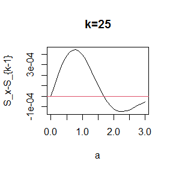

```r
#积分函数
int<-function(a,k){
  ck<-sqrt(a*a*k/(k+1-a*a))
  integrate(function(u) {(1+u*u/k)^(-(k+1)/2)},lower = 0,upper = ck)$value
}

Sk<-function(a,k){#计算
  2*exp(lgamma((k+1)/2)-log(sqrt(pi*k))-lgamma(k/2))*int(a,k)
}

k<-c(4:25,100,500,1000)
a<-seq(0,3,0.1)
y<-matrix(0,nrow=4,ncol = length(a))
for (i in 1:length(a)) {
  y[1,i]<-Sk(a[i],k[22])-Sk(a[i],k[22]-1)
  y[2,i]<-Sk(a[i],k[23])-Sk(a[i],k[23]-1)
  y[3,i]<-Sk(a[i],k[24])-Sk(a[i],k[24]-1)
  y[4,i]<-Sk(a[i],k[25])-Sk(a[i],k[25]-1)
}
#通过图来判断根所在的区间

plot(a,y[1,],type = "l",xlab = "a",ylab = "S_x-S_{k-1}",main = "k=25")
abline(h=0,col=2)
```

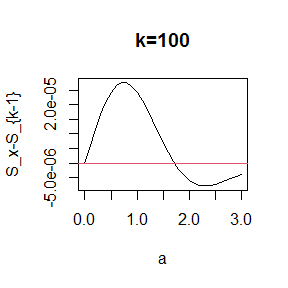

```r
plot(a,y[2,],type = "l",xlab = "a",ylab = "S_x-S_{k-1}",main = "k=100")
abline(h=0,col=2)
```

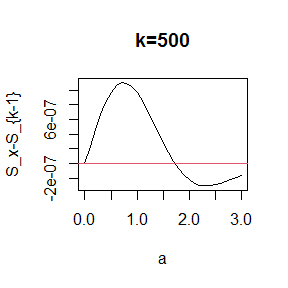

```r
plot(a,y[3,],type = "l",xlab = "a",ylab = "S_x-S_{k-1}",main = "k=500")
abline(h=0,col=2)
```

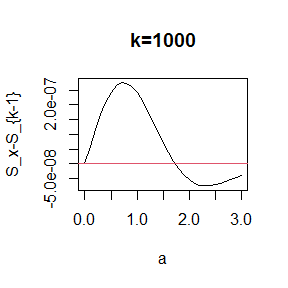

```r
plot(a,y[4,],type = "l",xlab = "a",ylab = "S_x-S_{k-1}",main = "k=1000")
abline(h=0,col=2)
```

由上图可以看出函数曲线在区间[1,2]间有交点。

```r
Ak<-function(k){
  uniroot(function(a) {Sk(a,k)-Sk(a,k-1)},interval=c(1,2))$root
}
root1<-rep(0,length(k))
for (i in 1:length(k)) {
  root1[i]<-Ak(k[i])
}
knitr::kable(rbind(c("k",k),c("root",round(root1,3))))
```

| k | 4 | 5 | 6 | 7 | 8 | 9 | 10 | 11 | 12 | 13 | 14 | 15 | 16 | 17 | 18 | 19 | 20 | 21 | 22 | 23 | 24 | 25 | 100 | 500 | 1000 |
| --- | --- | --- | --- | --- | --- | --- | --- | --- | --- | --- | --- | --- | --- | --- | --- | --- | --- | --- | --- | --- | --- | --- | --- | --- | --- |
| root | 1.492 | 1.534 | 1.563 | 1.584 | 1.601 | 1.615 | 1.625 | 1.634 | 1.642 | 1.649 | 1.654 | 1.659 | 1.663 | 1.667 | 1.671 | 1.674 | 1.677 | 1.679 | 1.681 | 1.684 | 1.686 | 1.687 | 1.721 | 1.73 | 1.731 |

11.4题

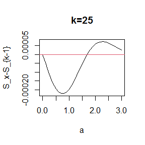

```r
Sk<-function(a,k){
  critical<-sqrt(a*a*k/(k+1-a*a))
  1-pt(critical,df=k)
}
k<-c(4:25,100,500,1000)
a<-seq(0,3,0.1)
#通过图来判断根所在的区间

plot(a,Sk(a,k[22])-Sk(seq(0,3,0.1),k[22]-1),type = "l",xlab = "a",ylab = "S_x-S_{k-1}",main = "k=25")
abline(h=0,col=2)
```

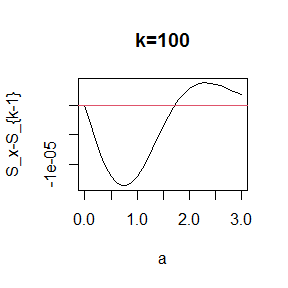

```r
plot(a,Sk(a,k[23])-Sk(seq(0,3,0.1),k[23]-1),type = "l",xlab = "a",ylab = "S_x-S_{k-1}",main = "k=100")
abline(h=0,col=2)
```

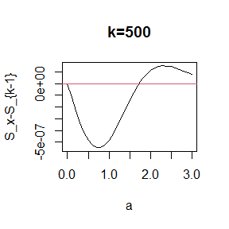

```r
plot(a,Sk(a,k[24])-Sk(seq(0,3,0.1),k[24]-1),type = "l",xlab = "a",ylab = "S_x-S_{k-1}",main = "k=500")
abline(h=0,col=2)
```

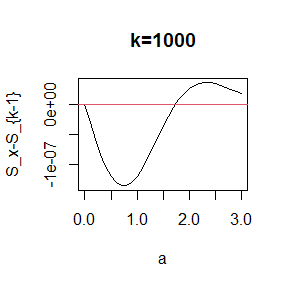

```r
plot(a,Sk(a,k[25])-Sk(seq(0,3,0.1),k[25]-1),type = "l",xlab = "a",ylab = "S_x-S_{k-1}",main = "k=1000")
abline(h=0,col=2)
```

由上图可以看出函数曲线在区间[1,2]间有交点。

```r
Ak<-function(k){#求解A(k)
  uniroot(function(a) {Sk(a,k)-Sk(a,k-1)},interval=c(1,2))$root
}
root2<-rep(0,length(k))
for (i in 1:length(k)) {
  root2[i]<-Ak(k[i])
}
knitr::kable(rbind(c("k",k),c("root",round(root2,3))))
```

| k | 4 | 5 | 6 | 7 | 8 | 9 | 10 | 11 | 12 | 13 | 14 | 15 | 16 | 17 | 18 | 19 | 20 | 21 | 22 | 23 | 24 | 25 | 100 | 500 | 1000 |
| --- | --- | --- | --- | --- | --- | --- | --- | --- | --- | --- | --- | --- | --- | --- | --- | --- | --- | --- | --- | --- | --- | --- | --- | --- | --- |
| root | 1.492 | 1.534 | 1.563 | 1.584 | 1.601 | 1.615 | 1.625 | 1.634 | 1.642 | 1.649 | 1.654 | 1.659 | 1.663 | 1.667 | 1.671 | 1.674 | 1.677 | 1.679 | 1.681 | 1.684 | 1.686 | 1.687 | 1.721 | 1.73 | 1.731 |

将11.5的结果与11.4的结果比较有

```r
knitr::kable(rbind(c("k",k),c("11.4",round(root2,3)),c("11.5",round(root1,3)),c("差",round(root1-root2,3))))
```

| k | 4 | 5 | 6 | 7 | 8 | 9 | 10 | 11 | 12 | 13 | 14 | 15 | 16 | 17 | 18 | 19 | 20 | 21 | 22 | 23 | 24 | 25 | 100 | 500 | 1000 |
| --- | --- | --- | --- | --- | --- | --- | --- | --- | --- | --- | --- | --- | --- | --- | --- | --- | --- | --- | --- | --- | --- | --- | --- | --- | --- |
| 11.4 | 1.492 | 1.534 | 1.563 | 1.584 | 1.601 | 1.615 | 1.625 | 1.634 | 1.642 | 1.649 | 1.654 | 1.659 | 1.663 | 1.667 | 1.671 | 1.674 | 1.677 | 1.679 | 1.681 | 1.684 | 1.686 | 1.687 | 1.721 | 1.73 | 1.731 |
| 11.5 | 1.492 | 1.534 | 1.563 | 1.584 | 1.601 | 1.615 | 1.625 | 1.634 | 1.642 | 1.649 | 1.654 | 1.659 | 1.663 | 1.667 | 1.671 | 1.674 | 1.677 | 1.679 | 1.681 | 1.684 | 1.686 | 1.687 | 1.721 | 1.73 | 1.731 |
| 差 | 0 | 0 | 0 | 0 | 0 | 0 | 0 | 0 | 0 | 0 | 0 | 0 | 0 | 0 | 0 | 0 | 0 | 0 | 0 | 0 | 0 | 0 | 0 | 0 | 0 |

两题结果一致。

### 3

Suppose $T_1,\cdots,T_n$ are i.i.d. samples drawn from the exponential distribution with expectation $\lambda$. Those values greater than $\tau$ are not observed due to right censorship, so that the observed values are $Y_i=T_iI(T_i\le\tau)+\tau I(T_i>\tau),\ i=1,\cdots,n$. Suppose $\tau=1$ and the observed $Y_i$ values are as follows: 0.54, 0.48, 0.33, 0.43, 1.00, 1.00, 0.91, 1.00, 0.21, 0.85 Use the E-M algorithm to estimate $\lambda$, compare your result with the observed data MLE (note: $Y_i$ follows a mixture distribution).

MLE求解：

令$y=(y_1,\cdots,y_{10})=(0.54, 0.48, 0.33, 0.43, 0.91, 0.21, 0.85, 1.00, 1.00, 1.00)$。而$Y_i$的密度函数为
$$\begin{equation*}
\left\{
\begin{array}{lr}
f(y)=\frac{1}{\lambda}e^{-y/\lambda},y\le 1\\
P(Y=1)=e^{-1/\lambda}\\
\end{array}
\right.
\end{equation*}$$
则联合密度函数为
$$\begin{equation*}
f(y)=\frac{1}{\lambda^7}e^{-\sum_{i=1}^{7}y_i/\lambda}e^{-3/\lambda}.
\end{equation*}$$
求解对数似然函数有

```r
y<-c(0.54,0.48,0.33,0.43,0.91,0.21,0.85,1.00,1.00,1.00)
l<-function(lambda){#似然函数
  -7*log(lambda)-sum(y[1:7])/lambda-3/lambda
}
optimize(l,interval = c(0.01,3),maximum = T)$maximum
```

```
## [1] 0.9642801
```

EM算法：

令完全数据为$X=(T_1,\cdots,T_{10},Y_1,\cdots,Y_{10})$，则此时的似然函数为
$$\begin{equation*}
\pi(\lambda|X)=\frac{1}{\lambda^7}e{-\frac{\sum_{i=1}^{10}t_i}{\lambda}}
\end{equation*}$$
E-M算法中的E步：
$$\begin{equation*}
Q(\lambda,\hat{\lambda}^{(i)})=E[-7\ln\lambda-\frac{\sum_{i=1}^{10}t_i}{\lambda}|X,\hat{\lambda}^{(i)}]=-7\ln\lambda-\sum_{i=1}^{7}y_i/\lambda-3E[t_i|X,\hat{\lambda}^{(i)}]/\lambda
\end{equation*}$$
其中$E[t_i|X,\hat{\lambda}^{(i)}]=1+\hat{\lambda}^{(i)}$，从而
$$\begin{equation*}
Q(\lambda,\hat{\lambda}^{(i)})=-7\ln\lambda-\sum_{i=1}^{7}y_i/\lambda-3(1+\hat{\lambda}^{(i)})/\lambda
\end{equation*}$$

```r
#E-M算法
EM<-function(y,max.it=10000,eps=1e-5){
  i<-1
  lambda1<-1
  lambda2<-2
  while (abs(lambda1-lambda2)>eps & i<max.it) {
    lambda1<-lambda2
    Q<-function(lambda){#E步
      -7*log(lambda)-sum(y[1:7])/lambda-3*(1+lambda1)/lambda
    }
    lambda2<-optimize(Q,interval = c(0.01,3),maximum = T)$maximum#M步
    i<-i+1
  }
  return(lambda2)
}
y<-c(0.54,0.48,0.33,0.43,0.91,0.21,0.85,1.00,1.00,1.00)
EM(y)
```

```
## [1] 1.687472
```

# 2021-11-25

## Question

Exercises 1 and 5 (page 204, Advanced R) Excecises 1 and 7 (page 214, Advanced R)

## Answer

### Exercises 1 (page 204, Advanced R)

```r
trims <- c(0, 0.1, 0.2, 0.5)
x <- rcauchy(100)
lapply(trims, function(trim) mean(x, trim = trim))
```

```
## [[1]]
## [1] -1.287194
##
## [[2]]
## [1] -0.25283
##
## [[3]]
## [1] -0.1897854
##
## [[4]]
## [1] -0.1868222
```

```r
lapply(trims, mean, x = x)
```

```
## [[1]]
## [1] -1.287194
##
## [[2]]
## [1] -0.25283
##
## [[3]]
## [1] -0.1897854
##
## [[4]]
## [1] -0.1868222
```

通过实验可以发现lapply()函数的两种调用可以得到相同的结果。

原因：调用lapply()函数的帮助文档可以看到lapply(X, FUN, …)，其中X是一个向量或者列表，即lapply()作用的对象，FUN则是施加于X的每一个元素的d函数，而…则是FUN的可选参数。对于第一种调用方式，lapply函数作用与trims，使用的函数为mean(x,trim=trim)，trims中的每一个元素作为mean函数的参数trim，x是预先生成的随机数。对于第二种调用方式，可以通过mean函数的帮助文档也可以看出mean(x, trim = 0, na.rm = FALSE, …)，其中x适用于求平均数的样本数据，trim则是从x中剔除数据的比例，故在对trims使用lapply时，FUN是mean函数，而…是“x=x”也即FUN的可选参数也即选定了求取平均数的样本，从而trims中的元素就作为mean函数中的trim参数使用，故两种调用方法的结果是一样的。

### Exercises 5 (page 204, Advanced R)

Exercises 3:

```r
data(mtcars)
formulas <- list(
mpg ~ disp,
mpg ~ I(1 / disp),
mpg ~ disp + wt,
mpg ~ I(1 / disp) + wt
)
rsq <- function(mod) summary(mod)$r.squared
lapply(formulas,function(x){
  mod<-lm(x,data = mtcars)
  rsq(mod)
})
```

```
## [[1]]
## [1] 0.7183433
##
## [[2]]
## [1] 0.8596865
##
## [[3]]
## [1] 0.7809306
##
## [[4]]
## [1] 0.8838038
```

Exercises 4:

```r
bootstraps <- lapply(1:10, function(i) {
  rows <- sample(1:nrow(mtcars), rep = TRUE)
  mtcars[rows, ]
})
rsq <- function(mod) summary(mod)$r.squared
lapply(bootstraps,function(x){
  mod<-lm(mpg ~ disp,data=x)
  rsq(mod)
})
```

```
## [[1]]
## [1] 0.6083954
##
## [[2]]
## [1] 0.6255956
##
## [[3]]
## [1] 0.7603951
##
## [[4]]
## [1] 0.7243168
##
## [[5]]
## [1] 0.8202593
##
## [[6]]
## [1] 0.7149485
##
## [[7]]
## [1] 0.8096765
##
## [[8]]
## [1] 0.6962249
##
## [[9]]
## [1] 0.6783824
##
## [[10]]
## [1] 0.8181409
```

### Exercises 1 (page 214, Advanced R)

```r
x1<-1:20
x2<-rnorm(20)
x3<-rep(5,20)
x<-data.frame(x1,x2,x3)#生成一个全是数据的dataframe
vapply(x,sd,numeric(1))#求解dataframe每一列数据的标准差
```

```
##        x1        x2        x3
## 5.9160798 0.9029419 0.0000000
```

```r
print(c(sd(x1),sd(x2),sd(x3)))#验证结果正确
```

```
## [1] 5.9160798 0.9029419 0.0000000
```

```r
x1<-rnorm(5)
x2<-c("a","b","c","d","e")
x3<-rep(5,5)
x4<-c("1","2","3","4","5")
x<-data.frame(x1,x2,x3,x4)#生成一个混合的dataframe
y<-vapply(x,is.numeric,logical(1))#判断全是数据的列
vapply(x[y],sd,numeric(1))#求数据列的标准差
```

```
##       x1       x3
## 1.227128 0.000000
```

### Exercises 7 (page 214, Advanced R)

```r
library(parallel)
cores<-detectCores()
cores
```

```
## [1] 4
```

```r
cluster<-makePSOCKcluster(cores)

boot_rsq <- function(i) {
  summary(lm(mpg ~ wt + disp, data = mtcars[sample(nrow(mtcars), rep = T), ]))$r.square
}

mcsapply<-function(x,f,...){
  res<-parLapply(cluster,x,f,...)
  simplify2array(res)
}

#简单检测正确性
sapply(1:10,sqrt)
```

```
##  [1] 1.000000 1.414214 1.732051 2.000000 2.236068 2.449490 2.645751 2.828427
##  [9] 3.000000 3.162278
```

```r
mcsapply(1:10,sqrt)
```

```
##  [1] 1.000000 1.414214 1.732051 2.000000 2.236068 2.449490 2.645751 2.828427
##  [9] 3.000000 3.162278
```

```r
parSapply(cluster,1:10,sqrt)
```

```
##  [1] 1.000000 1.414214 1.732051 2.000000 2.236068 2.449490 2.645751 2.828427
##  [9] 3.000000 3.162278
```

```r
#比较运行时间
system.time(sapply(1:500,boot_rsq))
```

```
## 用户 系统 流逝
## 0.48 0.00 0.48
```

```r
system.time(mcsapply(1:500,boot_rsq))
```

```
## 用户 系统 流逝
## 0.00 0.02 0.26
```

```r
system.time(parSapply(cluster,1:500,boot_rsq))
```

```
## 用户 系统 流逝
## 0.01 0.00 0.22
```

可以看出编写的mcsapply函数与sapply函数有相同的运行结果，但是计算效率大大提升。

```r
vapply2<-function(x,f,f.value,...){

  out<-matrix(rep(f.value,length(x)),nrow=length(x))
  for (i in sample(seq_along(x))) {#打乱计算顺序
    res<-f(unlist(x[i]),...)
    stopifnot(
      length(res)==length(f.value),
      typeof(res)==typeof(f.value)
    )
    out[i,]<-res

  }
  out
}

x1<-1:20
x2<-rnorm(20)
x3<-rep(5,20)
x<-data.frame(x1,x2,x3)#生成一个全是数据的dataframe
vapply(x,sd,numeric(1))#求解dataframe每一列数据的标准差
```

```
##       x1       x2       x3
## 5.916080 0.823764 0.000000
```

```r
vapply2(x,sd,numeric(1))
```

```
##          [,1]
## [1,] 5.916080
## [2,] 0.823764
## [3,] 0.000000
```

```r
x1<-rnorm(5)
x2<-c("a","b","c","d","e")
x3<-rep(5,5)
x4<-c("1","2","3","4","5")
x<-data.frame(x1,x2,x3,x4)#生成一个混合的dataframe
vapply(x,is.numeric,logical(1))#判断全是数据的列
```

```
##    x1    x2    x3    x4
##  TRUE FALSE  TRUE FALSE
```

```r
vapply2(x,is.numeric,logical(1))
```

```
##       [,1]
## [1,]  TRUE
## [2,] FALSE
## [3,]  TRUE
## [4,] FALSE
```

因为vapply在计算时每次都是独立的，故可以打乱顺序进行计算，因此mcvapply是可以实现的。

```r
cores<-detectCores()
cores
```

```
## [1] 4
```

```r
cluster<-makePSOCKcluster(cores)

mcvapply<-function(x,f,f.value,...){
  res<-mcsapply(x,f,...)
  for (i in sample(seq_along(x)))
    stopifnot(
      length(res[i])==length(f.value),
      typeof(res[i])==typeof(f.value)
    )
  res
}

x1<-1:20
x2<-rnorm(20)
x3<-rep(5,20)
x<-data.frame(x1,x2,x3)#生成一个全是数据的dataframe
mcvapply(x,sd,numeric(1))#求解dataframe每一列数据的标准差
```

```
##       x1       x2       x3
## 5.916080 1.138176 0.000000
```

```r
x1<-rnorm(5)
x2<-c("a","b","c","d","e")
x3<-rep(5,5)
x4<-c("1","2","3","4","5")
x<-data.frame(x1,x2,x3,x4)#生成一个混合的dataframe
mcvapply(x,is.numeric,logical(1))#判断全是数据的列
```

```
##    x1    x2    x3    x4
##  TRUE FALSE  TRUE FALSE
```

# 2021-12-02

## Question

1.Write an Rcpp function for Exercise 9.8 (page 278, Statistical Computing with R).

2.Compare the corresponding generated random numbers with pure R language using the function “qqplot”.

3.Campare the computation time of the two functions with the function “microbenchmark”.

4.Comments your results.

## Answer

### 1

```r
library(Rcpp)
library(microbenchmark)
```

```r
set.seed(123)

##Gibbs抽样的Cpp函数
cppFunction('NumericMatrix gibbsC(int n, double a, double b, int N, double x1, double y1) {
  NumericMatrix X(N,2);
  X(0,0)=x1;
  X(0,1)=y1;
  int i;
  double x;
  double y;

  for(i=1;i<N;i++){
    y=X(i-1,1);
    X(i,0)=rbinom(1,n,y)[0];
    x=X(i,0);
    X(i,1)=rbeta(1,x+a,n-x+b)[0];
  }
  return(X);
}')

##Gibbs抽样的R函数
gibbsR<-function(n,a,b,N,x1,y1){
  set.seed(1)
  #sigma为提议分布的标准差
  #N为链的长度
  #初始值为X1
  X<-matrix(0,N,2)#马尔可夫链
  X[1,]<-c(x1,y1)

  for (i in 2:N) {
    y<-X[i-1,2]
    x<-X[i,1]<-rbinom(1,n,prob = y)
    X[i,2]<-rbeta(1,shape1=x+a,shape2=n-x+b)
  }
  return(X)
}
```

### 2-3

令$n=10,\ a=2,\ b=3,\ N=1000$，初始值为$(2,0.5)$，去掉链的前500个值。

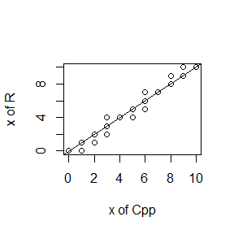

```r
#通过qq图比较两种语言写的函数生成的随机数
set.seed(123)
X<-gibbsC(10,2,3,1000,2,0.5)[-(1:500),]
Y<-gibbsR(10,2,3,1000,2,0.5)[-(1:500),]
qqplot(X[,1],Y[,1],xlab = "x of Cpp",ylab = "x of R")
abline(a=0,b=1)
```

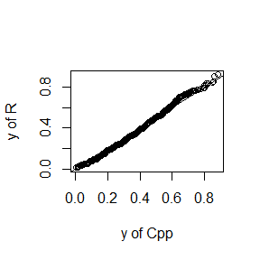

```r
qqplot(X[,2],Y[,2],xlab = "y of Cpp",ylab = "y of R")
abline(a=0,b=1)
```

```r
set.seed(123)
microbenchmark(gibbsC=gibbsC(10,2,3,1000,2,0.5),gibbsR=gibbsR(10,2,3,1000,2,0.5))
```

```
## Unit: microseconds
##    expr      min       lq      mean   median       uq       max neval
##  gibbsC  355.439  364.078  453.0613  372.365  528.222  3587.532   100
##  gibbsR 4030.066 4109.582 5862.6512 4177.812 6813.981 25935.724   100
```

改变参数，令$n=20,\ a=7,\ b=3,\ N=10000$，初始值为$(10,0.1)$，去掉链的前500个值。

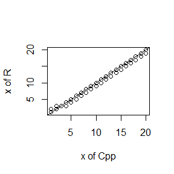

```r
#通过qq图比较两种语言写的函数生成的随机数
set.seed(123)
X<-gibbsC(20,7,3,10000,10,0.1)[-(1:500),]
Y<-gibbsR(20,7,3,10000,10,0.1)[-(1:500),]
qqplot(X[,1],Y[,1],xlab = "x of Cpp",ylab = "x of R")
abline(a=0,b=1)
```

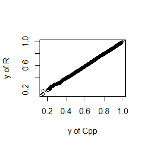

```r
qqplot(X[,2],Y[,2],xlab = "y of Cpp",ylab = "y of R")
abline(a=0,b=1)
```

```r
set.seed(123)
microbenchmark(gibbsC=gibbsC(20,7,3,10000,10,0.1),gibbsR=gibbsR(20,7,3,10000,10,0.1))
```

```
## Unit: milliseconds
##    expr       min        lq      mean    median        uq       max neval
##  gibbsC  3.622793  3.671454  3.803125  3.697195  3.770716  5.693716   100
##  gibbsR 40.939247 49.046805 49.789833 49.872107 52.262852 70.824991   100
```

### 4

通过上述实验我们可以看出利用两种语言进行Gibbs抽样生成的链的结果很相近，都可以得到我们想要的马尔科夫链，但是通过比较两种语言的运行时间可以看出利用Cpp语言写的函数运行更快。